## Optimizing resources in state transitions

In the Oberth maneuver, a spacecraft falls into a gravitational well and accelerates when at maximum speed. This is more efficient to gain kinetic energy as compared to applying impulse outside of the well. In fact, the most energy-efficient method is at the lowest possible orbital periapsis, when orbital velocity is maximized.

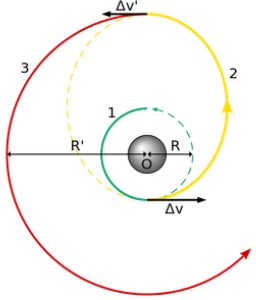

A Hohmann transfer orbit minimizes the amount of energy to gradually spiral out of an attractor by wisely benefiting from the gravitational pull.  
It is used to increase payload capacity considering a fixed amount of energy. European Swedish-designed satellite SMART-1 (2003) made use of this to spiral out of Earth until it deliberately crashed into the Moon (2006).

Knowing certain system characteristics gives information about moments to perturb the system in order to force transitions to new state spaces. As highlighted before, the states of biological neural populations are sucessfully modelled after attractor networks.